# Import Kallisto Data / Pre-processing

## 1. Import Kallisto Counts

- **Kallisto** (v0.45.0) was run on Phoenix as follows:

```r
# Use local version of kallisto v0.45 as it's not installed on phoenix
kallisto=/data/biohub/local/kallisto_linux-v0.45.0/kallisto

# Kallisto index:
$kallisto index -i $z11/index/kallisto_GRCz11.cdna.all.idx $z11_cdna
KALISTOIDX=/data/biohub/Refs/zebrafish/GRCz11_Ensembl/kallisto_primaryOnly_GRCz11_index

# Run Kallisto for each trimmed fastq file
cd $TRIMDATA/fastq
TRIM=`ls ${SLURM_ARRAY_TASK_ID}_*.fastq.gz`

# Because the data is single-end, we need to specify length -l and s.d -s of the fragment length
# We use the defaults for kallisto which are 200nt and 20nt s.d.
# mkdir -pv $QUANTDATA/transcriptLevel/${TRIM%%.fastq.gz}
OUTPUTDIR=/data/biohub/20170906_Morgan_Hypoxia/3_quantifiedData/kallisto_transcripts/${TRIM%%.fastq.gz}
$kallisto quant --genomebam --gtf $z11_gtf -t 16 --rf-stranded --single -b 100 -l 200 -s 20 -i $KALLISTOIDX -o $OUTPUTDIR $TRIM
```

### 1.1. catchKallisto()

- The **Kallisto** directories were imported into R using the `catchKallisto` function from *edgeR*:

```r
# Get paths to the Results directories generated by Kallisto.
kallistoResults <- "/Volumes/biohub/20170906_Morgan_Hypoxia/3_quantifiedData/transcriptLevel" %>%
  file.path %>%
  list.dirs
kallistoResults <- kallistoResults[-1] #The first dir is the root dir, which can be removed.
kallistoResults

############################################################################################################
# Import the kallisto results from the list of directories.
# Takes a while to run so I've saved the rds

importedKallisto <- catchKallisto(kallistoResults)
importedKallisto %>% saveRDS(here("R","DE","data","importedKallisto.rds"))

#############################################################################################################
# Make colnames neater / not include the full path
importedKallisto$counts %<>% set_colnames(basename(colnames(.))) %>%
  set_colnames(gsub(x=colnames(.),
                    pattern="^.*_(6|24)(Q|P)_P(N|H)([1-4]).*$",
                    replacement = "\\1\\2_P\\3\\4"))

str(importedKallisto)
```

### 1.2. Sample Information

- Load the sample spreadsheet including information like **Age**, **Genotype**, **Hypoxia/Normoxia**, and **Gender**.

| path | basename | id | Age | Genotype | Hypoxia | Gender | Group | sample |
| --- | --- | --- | --- | --- | --- | --- | --- | --- |
| /Volumes/biohub/20170906_Morgan_Hypoxia/3_quantifiedData/transcriptLevel/1_MORGAN_6P_PN1_S2_R1_001 | 1_MORGAN_6P_PN1_S2_R1_001 | 6P_PN1 | 6 | wt | 0 | male | wt_6_0 | wt_6_0_1 |
| /Volumes/biohub/20170906_Morgan_Hypoxia/3_quantifiedData/transcriptLevel/2_MORGAN_6P_PN2_S5_R1_001 | 2_MORGAN_6P_PN2_S5_R1_001 | 6P_PN2 | 6 | wt | 0 | female | wt_6_0 | wt_6_0_2 |
| /Volumes/biohub/20170906_Morgan_Hypoxia/3_quantifiedData/transcriptLevel/3_MORGAN_6P_PN3_S10_R1_001 | 3_MORGAN_6P_PN3_S10_R1_001 | 6P_PN3 | 6 | wt | 0 | female | wt_6_0 | wt_6_0_3 |
| /Volumes/biohub/20170906_Morgan_Hypoxia/3_quantifiedData/transcriptLevel/4_MORGAN_6P_PN4_S8_R1_001 | 4_MORGAN_6P_PN4_S8_R1_001 | 6P_PN4 | 6 | wt | 0 | female | wt_6_0 | wt_6_0_4 |
| /Volumes/biohub/20170906_Morgan_Hypoxia/3_quantifiedData/transcriptLevel/10_MORGAN_6P_PH2_S9_R1_001 | 10_MORGAN_6P_PH2_S9_R1_001 | 6P_PH2 | 6 | wt | 1 | female | wt_6_1 | wt_6_1_2 |
| /Volumes/biohub/20170906_Morgan_Hypoxia/3_quantifiedData/transcriptLevel/11_MORGAN_6P_PH3_S1_R1_001 | 11_MORGAN_6P_PH3_S1_R1_001 | 6P_PH3 | 6 | wt | 1 | female | wt_6_1 | wt_6_1_3 |
| /Volumes/biohub/20170906_Morgan_Hypoxia/3_quantifiedData/transcriptLevel/12_MORGAN_6P_PH4_S2_R1_001 | 12_MORGAN_6P_PH4_S2_R1_001 | 6P_PH4 | 6 | wt | 1 | female | wt_6_1 | wt_6_1_4 |
| /Volumes/biohub/20170906_Morgan_Hypoxia/3_quantifiedData/transcriptLevel/9_MORGAN_6P_PH1_S7_R1_001 | 9_MORGAN_6P_PH1_S7_R1_001 | 6P_PH1 | 6 | wt | 1 | female | wt_6_1 | wt_6_1_1 |
| /Volumes/biohub/20170906_Morgan_Hypoxia/3_quantifiedData/transcriptLevel/5_MORGAN_6Q_PN1_S3_R1_001 | 5_MORGAN_6Q_PN1_S3_R1_001 | 6Q_PN1 | 6 | q96 | 0 | female | q96_6_0 | q96_6_0_1 |
| /Volumes/biohub/20170906_Morgan_Hypoxia/3_quantifiedData/transcriptLevel/6_MORGAN_6Q_PN2_S4_R1_001 | 6_MORGAN_6Q_PN2_S4_R1_001 | 6Q_PN2 | 6 | q96 | 0 | female | q96_6_0 | q96_6_0_2 |

[output cut: 22 more lines]

### 1.3. Transcript-level counts

- Create matrix of the transcript-level count estimates with new names from the samples table:

| transcript_id | wt_6_0_1 | wt_6_0_2 | wt_6_0_3 | wt_6_0_4 | wt_6_1_2 | wt_6_1_3 | wt_6_1_4 | wt_6_1_1 | q96_6_0_1 | q96_6_0_2 | q96_6_0_3 | q96_6_0_4 | q96_6_1_1 | q96_6_1_2 | q96_6_1_3 | q96_6_1_4 | wt_24_0_1 | wt_24_0_2 | wt_24_0_3 | wt_24_0_4 | wt_24_1_1 | wt_24_1_2 | wt_24_1_3 | wt_24_1_4 | q96_24_0_1 | q96_24_0_2 | q96_24_0_3 | q96_24_0_4 | q96_24_1_1 | … |
| --- | --- | --- | --- | --- | --- | --- | --- | --- | --- | --- | --- | --- | --- | --- | --- | --- | --- | --- | --- | --- | --- | --- | --- | --- | --- | --- | --- | --- | --- | --- |
| ENSDART00000189226.1 | 0.000000e+00 | 0.000000e+00 | 0.000000e+00 | 0.000000e+00 | 0.000000e+00 | 0.000000e+00 | 0.000000e+00 | 0.000000e+00 | 0.000000e+00 | 0.000000e+00 | 0.000000e+00 | 0.000000e+00 | 0.000000e+00 | 0.000000e+00 | 0.000000e+00 | 0.000000e+00 | 0.000000e+00 | 0.000000e+00 | 0.000000e+00 | 0.000000e+00 | 0.000000e+00 | 0.000000e+00 | 0.000000e+00 | 0.000000e+00 | 0.000000e+00 | 0.000000e+00 | 0.000000e+00 | 0.000000e+00 | 0.000000e+00 | … |
| ENSDART00000189431.1 | 0.000000e+00 | 0.000000e+00 | 0.000000e+00 | 0.000000e+00 | 0.000000e+00 | 0.000000e+00 | 0.000000e+00 | 0.000000e+00 | 0.000000e+00 | 0.000000e+00 | 0.000000e+00 | 0.000000e+00 | 0.000000e+00 | 0.000000e+00 | 0.000000e+00 | 0.000000e+00 | 0.000000e+00 | 0.000000e+00 | 0.000000e+00 | 0.000000e+00 | 0.000000e+00 | 0.000000e+00 | 0.000000e+00 | 0.000000e+00 | 0.000000e+00 | 0.000000e+00 | 0.000000e+00 | 0.000000e+00 | 0.000000e+00 | … |
| ENSDART00000160762.2 | 0.000000e+00 | 2.000000e+00 | 0.000000e+00 | 0.000000e+00 | 0.000000e+00 | 0.000000e+00 | 0.000000e+00 | 0.000000e+00 | 1.000000e+00 | 2.000000e+00 | 0.000000e+00 | 2.000000e+00 | 4.000000e+00 | 0.000000e+00 | 1.000000e+00 | 0.000000e+00 | 0.000000e+00 | 0.000000e+00 | 0.000000e+00 | 0.000000e+00 | 0.000000e+00 | 0.000000e+00 | 0.000000e+00 | 0.000000e+00 | 0.000000e+00 | 0.000000e+00 | 0.000000e+00 | 0.000000e+00 | 0.000000e+00 | … |
| ENSDART00000170804.2 | 0.000000e+00 | 0.000000e+00 | 0.000000e+00 | 0.000000e+00 | 0.000000e+00 | 0.000000e+00 | 0.000000e+00 | 0.000000e+00 | 0.000000e+00 | 0.000000e+00 | 0.000000e+00 | 0.000000e+00 | 0.000000e+00 | 0.000000e+00 | 0.000000e+00 | 0.000000e+00 | 0.000000e+00 | 0.000000e+00 | 1.000000e+00 | 0.000000e+00 | 0.000000e+00 | 0.000000e+00 | 0.000000e+00 | 0.000000e+00 | 0.000000e+00 | 0.000000e+00 | 0.000000e+00 | 0.000000e+00 | 0.000000e+00 | … |
| ENSDART00000165410.2 | 1.000000e+00 | 6.000000e+00 | 1.484802e+00 | 1.000000e+00 | 5.000000e+00 | 1.274183e+01 | 4.000000e+00 | 1.000000e+00 | 3.000000e+00 | 1.000000e+00 | 0.000000e+00 | 0.000000e+00 | 2.388391e+00 | 1.321457e+00 | 4.000000e+00 | 1.200000e+01 | 3.000000e+00 | 0.000000e+00 | 1.000000e+00 | 1.000000e+00 | 1.000000e+00 | 2.000000e+00 | 0.000000e+00 | 3.000000e+00 | 0.000000e+00 | 1.192347e+00 | 3.000000e+00 | 0.000000e+00 | 2.000000e+00 | … |
| ENSDART00000163675.2 | 0.000000e+00 | 1.000000e+00 | 0.000000e+00 | 0.000000e+00 | 2.000000e+00 | 0.000000e+00 | 1.000000e+00 | 1.000000e+00 | 0.000000e+00 | 0.000000e+00 | 0.000000e+00 | 0.000000e+00 | 0.000000e+00 | 0.000000e+00 | 0.000000e+00 | 0.000000e+00 | 3.000000e+00 | 0.000000e+00 | 0.000000e+00 | 1.000000e+00 | 0.000000e+00 | 0.000000e+00 | 0.000000e+00 | 2.000000e+00 | 0.000000e+00 | 2.000000e+00 | 0.000000e+00 | 0.000000e+00 | 0.000000e+00 | … |
| ENSDART00000171132.2 | 0.000000e+00 | 0.000000e+00 | 0.000000e+00 | 0.000000e+00 | 0.000000e+00 | 0.000000e+00 | 0.000000e+00 | 0.000000e+00 | 0.000000e+00 | 0.000000e+00 | 0.000000e+00 | 0.000000e+00 | 0.000000e+00 | 0.000000e+00 | 0.000000e+00 | 0.000000e+00 | 0.000000e+00 | 0.000000e+00 | 0.000000e+00 | 0.000000e+00 | 0.000000e+00 | 0.000000e+00 | 0.000000e+00 | 0.000000e+00 | 0.000000e+00 | 2.000000e+00 | 0.000000e+00 | 0.000000e+00 | 0.000000e+00 | … |
| ENSDART00000172037.2 | 1.000000e+00 | 0.000000e+00 | 1.515198e+00 | 1.000000e+00 | 4.000000e+00 | 4.258169e+00 | 4.000000e+00 | 3.000000e+00 | 0.000000e+00 | 1.000000e+00 | 1.000000e+00 | 1.000000e+00 | 3.611609e+00 | 2.678543e+00 | 2.000000e+00 | 5.000000e+00 | 4.000000e+00 | 5.000000e+00 | 2.000000e+00 | 2.000000e+00 | 1.000000e+00 | 5.000000e+00 | 1.000000e+00 | 5.000000e+00 | 4.000000e+00 | 4.807653e+00 | 3.000000e+00 | 0.000000e+00 | 3.000000e+00 | … |
| ENSDART00000161368.2 | 0.000000e+00 | 0.000000e+00 | 0.000000e+00 | 0.000000e+00 | 1.000000e+00 | 0.000000e+00 | 1.000000e+00 | 0.000000e+00 | 0.000000e+00 | 0.000000e+00 | 0.000000e+00 | 0.000000e+00 | 2.000000e+00 | 0.000000e+00 | 0.000000e+00 | 0.000000e+00 | 0.000000e+00 | 0.000000e+00 | 0.000000e+00 | 0.000000e+00 | 0.000000e+00 | 0.000000e+00 | 0.000000e+00 | 0.000000e+00 | 0.000000e+00 | 0.000000e+00 | 0.000000e+00 | 0.000000e+00 | 0.000000e+00 | … |
| ENSDART00000172374.2 | 0.000000e+00 | 0.000000e+00 | 0.000000e+00 | 0.000000e+00 | 0.000000e+00 | 0.000000e+00 | 0.000000e+00 | 1.000000e+00 | 0.000000e+00 | 0.000000e+00 | 1.000000e+00 | 0.000000e+00 | 3.000000e+00 | 0.000000e+00 | 0.000000e+00 | 0.000000e+00 | 0.000000e+00 | 2.000000e+00 | 0.000000e+00 | 3.000000e+00 | 0.000000e+00 | 0.000000e+00 | 0.000000e+00 | 0.000000e+00 | 0.000000e+00 | 0.000000e+00 | 0.000000e+00 | 0.000000e+00 | 0.000000e+00 | … |

[output cut: 990 more lines]

### 1.4. Gene-Transcript Annotation

- To summarise to gene-level counts, we first need to prepare a `data.frame` that maps from Ensembl transcript to gene IDs.

| transcript_id | tx_id_version | gene_id |
| --- | --- | --- |
| ENSDART00000164359 | ENSDART00000164359.1 | ENSDARG00000099104 |
| ENSDART00000157701 | ENSDART00000157701.1 | ENSDARG00000099104 |
| ENSDART00000158290 | ENSDART00000158290.1 | ENSDARG00000099104 |
| ENSDART00000167898 | ENSDART00000167898.1 | ENSDARG00000099104 |
| ENSDART00000166393 | ENSDART00000166393.1 | ENSDARG00000102407 |
| ENSDART00000161842 | ENSDART00000161842.1 | ENSDARG00000102407 |
| ENSDART00000170877 | ENSDART00000170877.1 | ENSDARG00000102407 |
| ENSDART00000165461 | ENSDART00000165461.1 | ENSDARG00000102407 |
| ENSDART00000171631 | ENSDART00000171631.1 | ENSDARG00000102407 |
| ENSDART00000169005 | ENSDART00000169005.1 | ENSDARG00000102407 |

[output cut: 990 more lines]

### 1.5. Gene-level counts

- Now we can summarise the transcript-level count estimates to gene-level count estimates by summing together the transcript-level counts corresponding to the same gene. We will also use the new names from the `samples` table.

| gene_id | wt_6_0_1 | wt_6_0_2 | wt_6_0_3 | wt_6_0_4 | wt_6_1_2 | wt_6_1_3 | wt_6_1_4 | wt_6_1_1 | q96_6_0_1 | q96_6_0_2 | q96_6_0_3 | q96_6_0_4 | q96_6_1_1 | q96_6_1_2 | q96_6_1_3 | q96_6_1_4 | wt_24_0_1 | wt_24_0_2 | wt_24_0_3 | wt_24_0_4 | wt_24_1_1 | wt_24_1_2 | wt_24_1_3 | wt_24_1_4 | q96_24_0_1 | q96_24_0_2 | q96_24_0_3 | q96_24_0_4 | q96_24_1_1 | … |
| --- | --- | --- | --- | --- | --- | --- | --- | --- | --- | --- | --- | --- | --- | --- | --- | --- | --- | --- | --- | --- | --- | --- | --- | --- | --- | --- | --- | --- | --- | --- |
| ENSDARG00000000001 | 196.906989 | 336.300104 | 262.922831 | 220.824940 | 249.864000 | 463.472244 | 214.269727 | 214.616632 | 159.645503 | 175.876603 | 256.975112 | 140.689811 | 390.025333 | 241.328974 | 258.741925 | 249.451453 | 314.170348 | 330.825720 | 286.362507 | 273.496931 | 287.661609 | 319.738726 | 255.374173 | 222.879143 | 276.154547 | 218.883128 | 235.385800 | 188.894282 | 144.754118 | … |
| ENSDARG00000000002 | 131.093011 | 217.699896 | 170.077169 | 167.175060 | 141.136000 | 273.527756 | 303.730273 | 149.383368 | 194.354497 | 137.123397 | 165.024888 | 133.310189 | 292.974667 | 268.671026 | 250.258075 | 231.548547 | 410.829652 | 330.174280 | 389.637493 | 353.503069 | 222.338391 | 319.261274 | 245.625827 | 312.120857 | 319.845453 | 330.116872 | 424.614200 | 327.105718 | 402.245882 | … |
| ENSDARG00000000018 | 592.000000 | 1065.000000 | 752.000000 | 829.000000 | 795.000000 | 1241.000000 | 913.000000 | 828.000000 | 621.000000 | 586.000000 | 800.000000 | 569.000000 | 1475.000000 | 864.000000 | 925.000000 | 966.000000 | 790.000000 | 948.000000 | 838.000000 | 829.000000 | 761.000000 | 876.000000 | 767.000000 | 823.000000 | 886.000000 | 717.000000 | 775.000000 | 728.000000 | 667.000000 | … |
| ENSDARG00000000019 | 3204.000000 | 5108.000000 | 3561.000000 | 3872.000000 | 3405.000000 | 5793.000000 | 4741.000000 | 3694.000000 | 3164.000000 | 3247.000000 | 4069.000000 | 3281.000000 | 5717.000000 | 4464.000000 | 4666.000000 | 4517.000000 | 4693.000000 | 4229.000000 | 4344.000000 | 4888.000000 | 3830.000000 | 3830.000000 | 3809.000000 | 4375.000000 | 4864.000000 | 3647.000000 | 4772.000000 | 4603.000000 | 3720.000000 | … |
| ENSDARG00000000068 | 217.000000 | 441.000000 | 302.000000 | 285.000000 | 326.000000 | 535.000000 | 342.000000 | 297.000000 | 243.000000 | 233.000000 | 288.000000 | 180.000000 | 503.000000 | 330.000000 | 367.000000 | 374.000000 | 398.000000 | 457.000000 | 444.000000 | 444.000000 | 369.000000 | 364.000000 | 429.000000 | 295.000000 | 397.000000 | 389.000000 | 360.000000 | 351.000000 | 367.000000 | … |
| ENSDARG00000000069 | 334.441047 | 565.881787 | 409.992651 | 506.208337 | 478.934219 | 662.866429 | 637.720552 | 539.947378 | 378.610374 | 393.253235 | 471.690081 | 316.801930 | 611.887743 | 521.106185 | 504.890584 | 519.783617 | 519.901214 | 617.868064 | 517.767920 | 543.617289 | 436.861057 | 470.945895 | 456.247008 | 433.329847 | 553.360261 | 485.593515 | 506.862537 | 500.937413 | 545.647496 | … |
| ENSDARG00000000086 | 3358.000000 | 6052.000000 | 4111.000000 | 4067.000000 | 3846.000000 | 6467.000000 | 3811.000000 | 3705.000000 | 3447.000000 | 3161.000000 | 4360.000000 | 2993.000000 | 6447.000000 | 4771.000000 | 5116.000000 | 4848.000000 | 5493.000000 | 5746.000000 | 5242.000000 | 5663.000000 | 4770.000000 | 4417.000000 | 5439.000000 | 4957.000000 | 4523.000000 | 3934.961137 | 5618.936672 | 4932.000000 | 3543.000000 | … |
| ENSDARG00000000103 | 4504.479756 | 8190.003697 | 5061.458814 | 5567.762452 | 4828.285498 | 8239.233200 | 6452.402251 | 4643.359418 | 5254.469897 | 4430.542542 | 5696.325382 | 4545.493287 | 8941.718713 | 6870.327472 | 6952.002811 | 6777.005568 | 7183.288548 | 7334.286116 | 6409.268335 | 7410.674137 | 6116.838241 | 5979.661510 | 6660.442795 | 6193.931905 | 6546.764727 | 5172.999915 | 6541.430724 | 6237.088418 | 5902.436337 | … |
| ENSDARG00000000142 | 331.000000 | 542.000000 | 377.000000 | 383.000000 | 405.000000 | 742.000000 | 311.000000 | 451.000000 | 262.000000 | 317.000000 | 330.000000 | 241.000000 | 646.000000 | 340.000000 | 419.000000 | 484.000000 | 414.000000 | 482.000000 | 522.000000 | 516.000000 | 492.000000 | 540.000000 | 493.000000 | 442.000000 | 436.000000 | 364.000000 | 501.000000 | 306.000000 | 246.000000 | … |
| ENSDARG00000000151 | 320.000000 | 564.000000 | 409.000000 | 365.000000 | 502.000000 | 848.000000 | 457.000000 | 499.000000 | 314.000000 | 298.000000 | 465.000000 | 266.000000 | 980.000000 | 514.000000 | 807.000000 | 586.000000 | 474.000000 | 533.000000 | 454.000000 | 569.000000 | 515.000000 | 833.000000 | 679.000000 | 562.000000 | 474.000000 | 466.000000 | 444.000000 | 398.000000 | 420.000000 | … |

[output cut: 990 more lines]

### 1.5. Export counts

- Finally, export out the relevant objects.

```r
#counts_t %>% saveRDS(here("R","DE","data","counts_t.rds"))
#counts_g %>% saveRDS(here("R","DE","data", "counts_g.rds"))
```

## 2. Prepare DGEList

- We will store gene and transcript count estimates as DGEList objects for differential gene/transcript analysis later. DGEList objects also contain gene/transcript annotation and sample annotation.
- The DGEList for gene-level counts was created as follows:

```r
counts_for_dge <- counts_g %>% column_to_rownames("gene_id") %>% as.matrix

genes_for_dge <- data.frame(ensembl_gene_id = rownames(counts_for_dge)) %>%
  left_join(as.data.frame(genes) %>% dplyr::select(gene_id, gene_name, gene_biotype, entrezid, description),
            by = c("ensembl_gene_id"="gene_id"))

samples_for_dge <- sample_to_cov %>% set_rownames(.$sample)

dge <- DGEList(counts = counts_for_dge,
               genes = genes_for_dge,
               samples = samples_for_dge,
               remove.zeros = TRUE) %>%
  calcNormFactors("TMM")

dge

#saveRDS(dge, here("R","DE","data","dge_g.rds"))
```

- The DGEList for transcript-level counts was created as follows:

```r
counts_for_dge_t <- counts_t %>% as.data.frame %>% rownames_to_column("ensembl_transcript_id") %>%
  magrittr::extract(, c("ensembl_transcript_id", sample_to_cov$sample)) %>%
  column_to_rownames("ensembl_transcript_id") %>% as.matrix

transcripts_for_dge_t <- data.frame(ensembl_transcript_id = rownames(counts_t)) %>%
  left_join(mapTx2Gene, by = c("ensembl_transcript_id"="tx_id_version")) %>%
  left_join(as.data.frame(genes) %>% dplyr::select(gene_id, gene_name, gene_biotype, entrezid, description),
            by = c("gene_id"))%>%
  dplyr::rename(ensembl_gene_id = gene_id)

dge_t <- DGEList(counts = counts_for_dge_t,
                 genes = transcripts_for_dge_t,
                 samples = samples_for_dge, remove.zeros = TRUE) %>%
  calcNormFactors("TMM")

dge_t

# saveRDS(dge_t, here("R","DE","data","dge_t.rds"))
```

## 3. Visualisation

We will use Principal Component Analysis to get an idea of the similarity of samples / libraries based on their gene and transcript expression.

### 3.1. Gene level PCA

```r
pca_analysis1 <- prcomp(t(cpm(dge, log=TRUE)))
summary(pca_analysis1)
```

```
Importance of components:
                           PC1      PC2      PC3      PC4      PC5      PC6      PC7      PC8      PC9    PC10     PC11     PC12     PC13     PC14     PC15     PC16     PC17     PC18     PC19     PC20
Standard deviation     32.7870 18.28904 17.55036 16.39476 15.76348 14.97463 13.82294 13.55283 12.99557 12.6928 12.43654 12.34447 11.80978 11.77567 11.59993 11.44900 11.28625 11.09098 10.94333 10.85024
Proportion of Variance  0.1915  0.05959  0.05488  0.04789  0.04427  0.03995  0.03404  0.03272  0.03009  0.0287  0.02756  0.02715  0.02485  0.02471  0.02397  0.02335  0.02269  0.02192  0.02134  0.02097
Cumulative Proportion   0.1915  0.25112  0.30599  0.35388  0.39815  0.43810  0.47214  0.50487  0.53496  0.5637  0.59122  0.61837  0.64321  0.66792  0.69189  0.71525  0.73794  0.75986  0.78119  0.80217
                           PC21     PC22     PC23     PC24     PC25     PC26    PC27    PC28    PC29    PC30    PC31      PC32
Standard deviation     10.74742 10.67808 10.62998 10.47855 10.17287 10.08982 9.98698 9.76654 9.50397 9.26861 9.02472 6.269e-14
Proportion of Variance  0.02058  0.02031  0.02013  0.01956  0.01844  0.01814 0.01777 0.01699 0.01609 0.01531 0.01451 0.000e+00
Cumulative Proportion   0.82274  0.84306  0.86319  0.88275  0.90119  0.91933 0.93710 0.95409 0.97018 0.98549 1.00000 1.000e+00
```

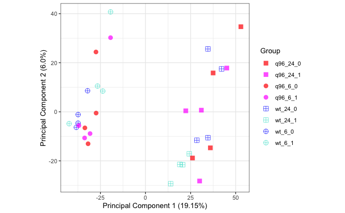

```r
pca_analysis1$x %>% magrittr::extract(, c("PC1", "PC2")) %>%
  as.data.frame %>%
  rownames_to_column("samples") %>%
  left_join((dge$samples %>% rownames_to_column("samples")), by="samples") %>%
    ggplot(aes(x=PC1, y = PC2, colour = Group, shape = Group)) +
    geom_point(alpha = 0.7,size=3) +
    scale_shape_manual(values = c(15,15,16,16,12,12,10,10)) +
    theme(aspect.ratio = 1) +
    #scale_color_brewer(palette ="Paired") +
    scale_color_manual(values = c("red", "magenta", "red", "magenta", "blue", "turquoise", "blue", "turquoise"))+
    labs(x = "Principal Component 1 (19.15%)", y = "Principal Component 2 (6.0%)",
         colour = "Group", shape = "Group")
```

### 3.2. Transcript level PCA:

```r
pca_analysis2 <- prcomp(t(cpm(dge_t, log=TRUE)))
summary(pca_analysis2)
```

```
Importance of components:
                            PC1      PC2      PC3      PC4      PC5      PC6      PC7     PC8     PC9     PC10     PC11     PC12     PC13     PC14     PC15     PC16     PC17     PC18    PC19     PC20
Standard deviation     56.78405 51.82830 37.29501 36.39899 36.01298 34.60935 33.67738 33.3095 32.9466 32.50815 32.33148 31.84497 31.61266 31.56106 31.32408 31.10396 30.80951 30.68094 30.4077 30.07399
Proportion of Variance  0.09416  0.07844  0.04062  0.03869  0.03787  0.03498  0.03312  0.0324  0.0317  0.03086  0.03053  0.02961  0.02918  0.02909  0.02865  0.02825  0.02772  0.02749  0.0270  0.02641
Cumulative Proportion   0.09416  0.17261  0.21323  0.25192  0.28979  0.32477  0.35789  0.3903  0.4220  0.45285  0.48338  0.51300  0.54218  0.57127  0.59992  0.62818  0.65590  0.68339  0.7104  0.73680
                           PC21     PC22     PC23    PC24     PC25     PC26     PC27     PC28     PC29     PC30     PC31      PC32
Standard deviation     29.96837 29.51886 29.32277 29.2610 29.10832 28.69511 28.52838 28.37738 27.76743 27.50246 26.64469 1.992e-13
Proportion of Variance  0.02623  0.02545  0.02511  0.0250  0.02474  0.02405  0.02377  0.02352  0.02252  0.02209  0.02073 0.000e+00
Cumulative Proportion   0.76303  0.78848  0.81358  0.8386  0.86333  0.88738  0.91115  0.93466  0.95718  0.97927  1.00000 1.000e+00
```

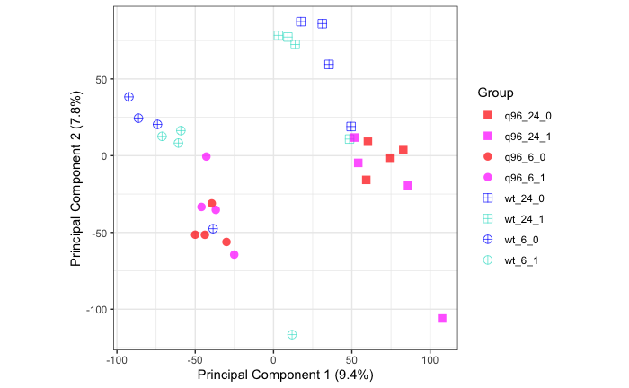

```r
pca_analysis2$x %>% magrittr::extract(, c("PC1", "PC2")) %>%
  as.data.frame %>%
  rownames_to_column("samples") %>%
  left_join((dge$samples %>% rownames_to_column("samples")), by="samples") %>%
    ggplot(aes(x=PC1, y = PC2, colour = Group, shape = Group)) +
    geom_point(alpha = 0.7,size=3) +
    scale_shape_manual(values = c(15,15,16,16,12,12,10,10)) +
    theme(aspect.ratio = 1) +
    #scale_color_brewer(palette ="Paired") +
    scale_color_manual(values = c("red", "magenta", "red", "magenta", "blue", "turquoise", "blue", "turquoise"))+
    labs(x = "Principal Component 1 (9.4%)", y = "Principal Component 2 (7.8%)",
         colour = "Group", shape = "Group")
```

## 4. Filtering

### 4.1. Gene-level filtering

We chose the threshold of at least 1 cpm in at least 4 samples based on the following density plots.

```r
keepTheseGenes <- (rowSums(cpm(dge) > 1) >= 4)
A <- dge %>%
  cpm(log = TRUE) %>%
  melt %>%
  dplyr::filter(is.finite(value)) %>%
  ggplot(aes(x = value, colour = Var2)) +
  geom_density() +
  guides(colour = FALSE) +
  ggtitle("A. Before filtering") +
  labs(x = "logCPM", y = "Density")
B <- dge %>%
  cpm(log = TRUE) %>%
  magrittr::extract(keepTheseGenes,) %>%
  melt %>%
  dplyr::filter(is.finite(value)) %>%
  ggplot(aes(x = value, colour = Var2)) +
  geom_density() +
  guides(colour = FALSE) +
  ggtitle("B. After filtering")+
  labs(x = "logCPM", y = "Density")
grid.newpage()
vp1 <- viewport(x = 0, y = 0, width = 0.5, height = 1, just = c(0, 0))
vp2 <- viewport(x = 0.5, y = 0, width = 0.5, height = 1, just = c(0,0))
print(A, vp = vp1)
```

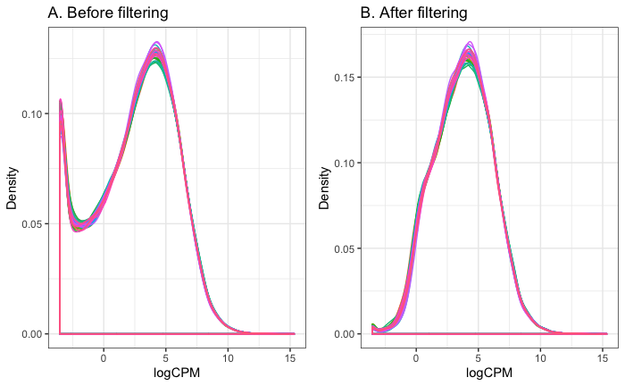

```r
print(B, vp  = vp2)
```

- Using this threshold, we filtered out 5323 genes from the original 25030 genes, giving the remaining 19707 to be used in the analysis.

```r
saveRDS(dge_g, here("R","DE","data","dge_g_filtered.rds"))
```

[output not shown]

### 4.2. Transcript level filtering

The threshold for filtering (at least 1 cpm in at least 4 samples) was chosen to be consistent with the gene level filtering.

```r
keepTheseTx <- (rowSums(cpm(dge_t) > 1) >= 4)
A <- dge_t %>%
  cpm(log = TRUE) %>%
  melt %>%
  dplyr::filter(is.finite(value)) %>%
  ggplot(aes(x = value, colour = Var2)) +
  geom_density() +
  guides(colour = FALSE) +
  ggtitle("A. Before filtering") +
  labs(x = "logCPM", y = "Density")
B <- dge_t %>%
  cpm(log = TRUE) %>%
  magrittr::extract(keepTheseTx,) %>%
  melt %>%
  dplyr::filter(is.finite(value)) %>%
  ggplot(aes(x = value, colour = Var2)) +
  geom_density() +
  guides(colour = FALSE) +
  ggtitle("B. After filtering")+
  labs(x = "logCPM", y = "Density")
grid.newpage()
vp1 <- viewport(x = 0, y = 0, width = 0.5, height = 1, just = c(0, 0))
vp2 <- viewport(x = 0.5, y = 0, width = 0.5, height = 1, just = c(0,0))
print(A, vp = vp1)
```

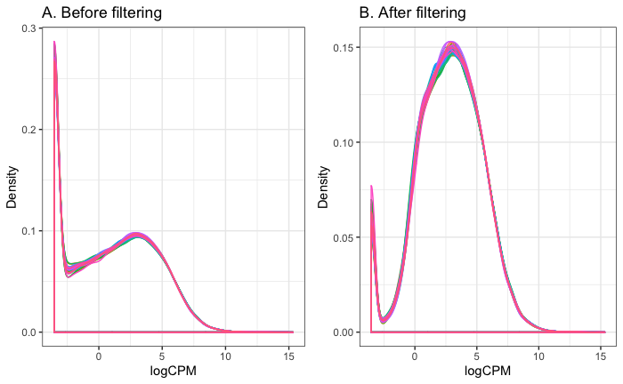

```r
print(B, vp  = vp2)
```

- Using this threshold, we filtered out 17356 transcripts from the original 48522 transcripts, giving the remaining 31166 to be used in the analysis.

```r
dge_t <- dge_t[keepTheseTx,,keep.lib.sizes = FALSE]
saveRDS(dge_t, here("R","DE","data","dge_t_filtered.rds"))
```